# PM2.5 on the London Underground

8 January 2020

## Introduction

## About me

- MSc in GIS at UCL
- PhD / Researcher at King’s College London
- The London Hybrid Exposure Model / Air quality GIS ‘stuff’

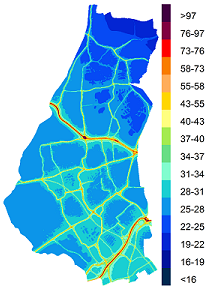

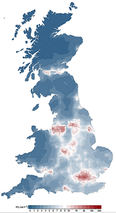

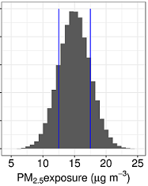

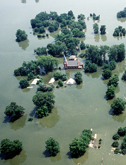

- Now at Guy Carpenter (Model development, Re-insurance)

## Why measure air on the tube

- Exposure to particles on subway systems > important
- Seaton et al 2005, but …
  - Tox. mechanisms
  - Susceptible populations
  - Analytical techniques

## Aims

## What we tried to do

- Measure variations in PM<sub>2.5</sub> between lines and stations
- Characterise the chemical composition
- Calculate calibration factors for optical instruments
- Provide a spatially resolved dataset for future analysis

[figure not shown]

## Method

## Mobile Measurement campaign

- TSI AM510 SidePak (PM2.5) + Philips Aerasense (numbers and size of particles)
- 31 hours, all lines
- 89% of stations (NE Central, SW Piccadilly)
- A long time down there with some fancy science equipment

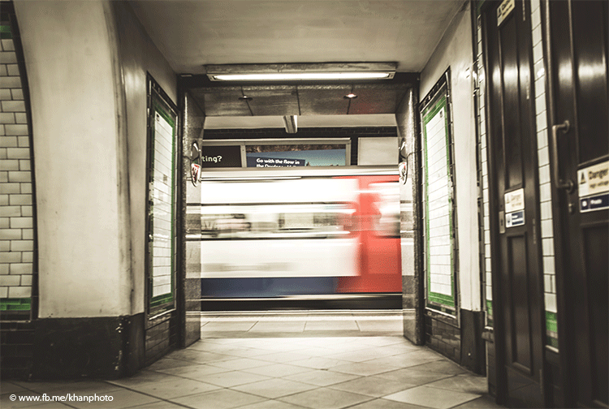

## Geo-tagging data

- Need to link air quality measurements to locations
- No GPS signal on large sections of the network
- Considered using timetables / interpolating between known locations
- Ended up using a notepad

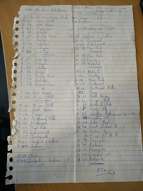

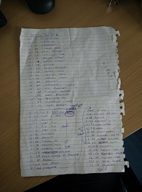

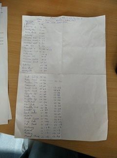

## Characterisation & Calibration

- Particles collected on filters over 5 days measuring composition & amount
- High time resolution equipment installed
  - Aethalometer / TSI Dustrak / 2 TSI Sidepaks / Micro-aethalometer
- Some *really* fancy equipment on the platform at Hampstead

[figure not shown]

## Passenger-weighted stations

- 2015 tap in/tap out, Underground performance report
- Annual in/out for each station
- Mean PM<sub>2.5</sub> measured at each station
- Passenger rank * air quality rank = passenger-weighted ranking

[figure not shown]

## Spatial representation of the tube

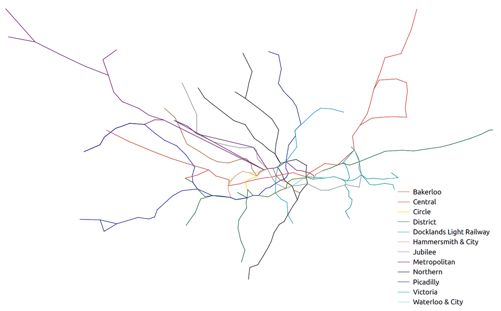

## Results

## Calibration factors

- Linear model to calculate correction factors for mobile monitoring equipment
- Mobile monitoring equipment co-located in tube station v. outdoor

[figure not shown]

## The Victoria Line

[figure not shown]

## Line averages

[figure not shown]

## Station depth 1

[figure not shown]

## Station depth 2

[figure not shown]

## Depth on the Central Line

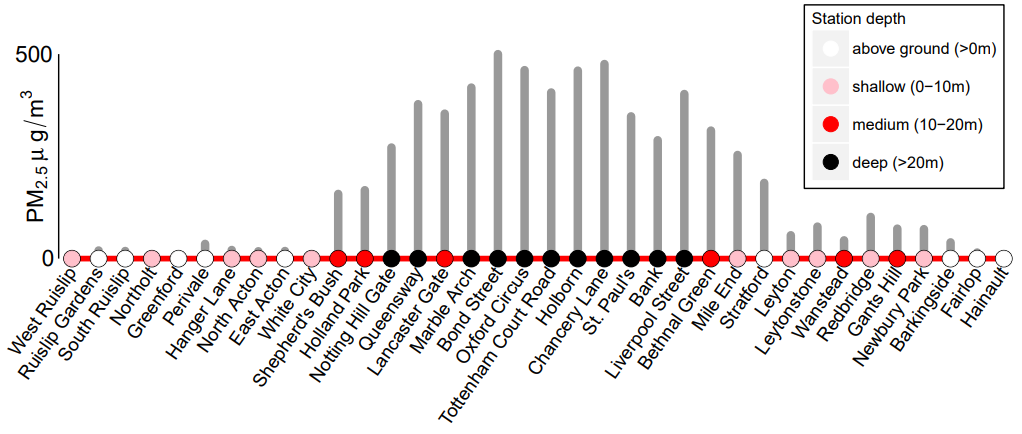

## PM<sub>2.5</sub> Map

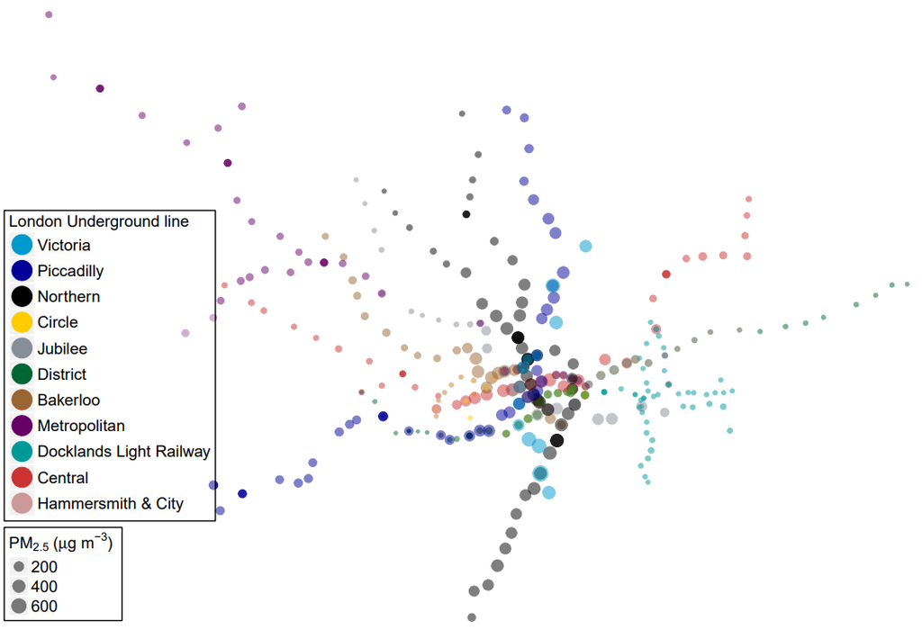

## PM<sub>2.5</sub> online map

[Online](http://www.erg.kcl.ac.uk/research/home/projects/TubeMapPM25.html)

[figure not shown]

## Passenger-weighted stations

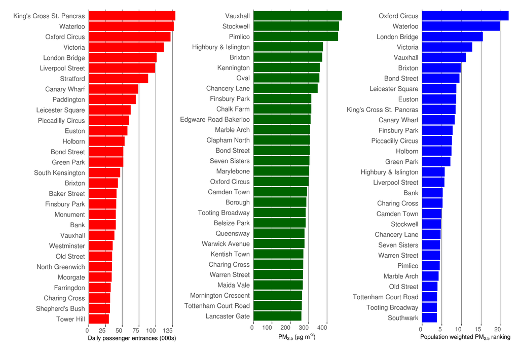

## Origin-Destination matrix

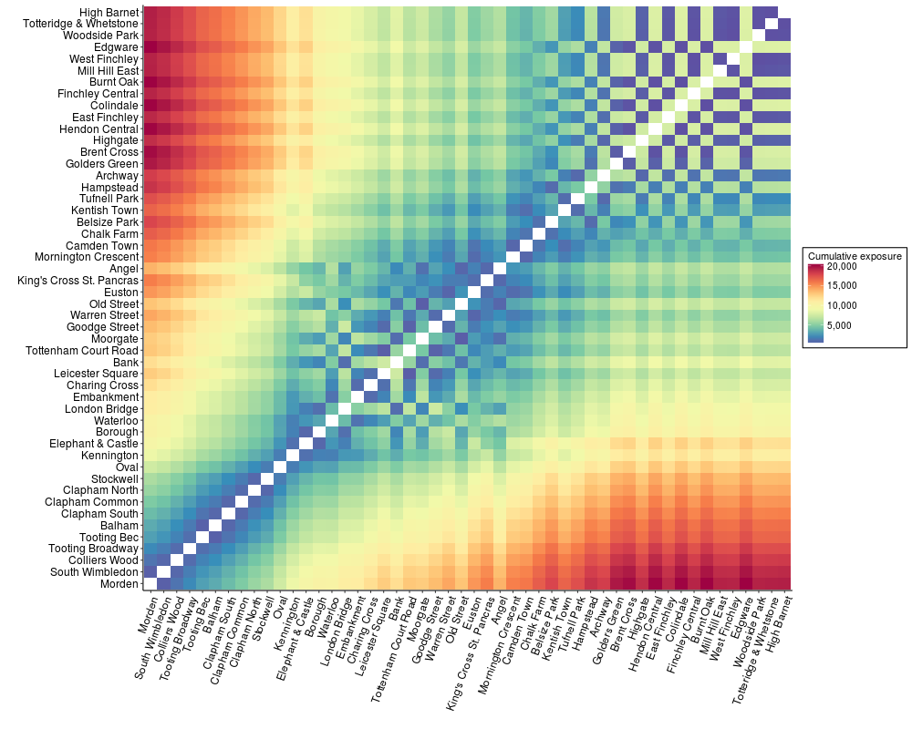

## Characterisation

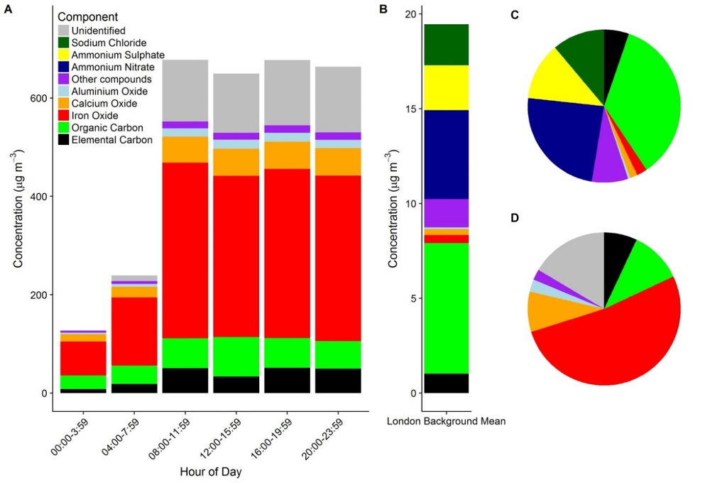

## Conclusions

## Conclusions

- Particles tend to be larger in diameter than those at background or roadside environments
- More particles
- PM<sub>2.5</sub> varied between lines & locations
  - lowest Hammersmith & City (Mean 25 µg/m3), similar to roadside
  - highest Victoria (381 µg/m3), 15 x higher than roadside
- There’s lots, they’re bigger than exhaust, and it really varies

## Conclusions 2

- Relationship between ‘depth’ and air quality
- Oxford Circus, Waterloo, London Bridge, Victoria and Vauxhall = bleurgh
- We now know what most of it is
- Other studies need to re-evaluate

## What next

## What was planned

- Characterise the remaining 11%
- More measurements accross the network to improve understanding
  - train frequency
  - passenger numbers
  - time of year
- Interventions?
- Develop inclusion in exposure modelling

## What happened

[figure not shown]

## The end

## Publication, Contact & Data

[figure not shown]

https://data.mendeley.com/datasets/tv56txbpcw/1

james.david.smith@gmail.com

[TheRealJimShady](http://twitter.com/therealjimshady)